# 36-315 Homework 08, Fall 2021

Your Name Here

Due Tuesday, November 2, 2021 (11:59pm ET) on Gradescope

# Homework 08: Dendrograms and Principal Component Analysis

# Problem 0: Project Group Logistics, and Identifying Potential Datasets (25 points)

For this problem, your team must email the Head TA (Trey McNeely, imcneely@andrew.cmu.edu) and me (zach@stat.cmu.edu) a few logistical details about the final project. The team as a whole only has to send a single email, with all the teammates CC’d. Thus, to receive credit for this Problem 0, please email us the following details by **Friday, November 5** at the latest (but the sooner the better). Your submission for this can simply be in the email text itself, a Google Doc, or any other format that you choose. For this problem, you don’t have to include anything in the Homework8 submission; so, you can delete this Problem 0 after you have emailed us.

- 5pts: **Group Meeting Time**: It’s very important that your group come up with a logistical game plan for how you are going to work together for the next month. Write down a weekly one-hour block when everyone in your group can meet to discuss the project. Portions of future assignments will ask for mini updates on your group project, so it is important that your group coordinate a regular time to meet.
- 5pts: **Mode of Collaboration**: In one paragraph, write down your team’s plan for collaborating. For example, will you have a shared Box, Google Drive, Slack, GitHub, etc. to share files, code, and other things? How will the work be divided amongst the group? Other details about how you plan to work as a group? (Of course, you can change your collaborative plan as you go along, but for now, you should have a tentative plan that you have discussed with your group.)
- 15pts: **Two Potential Datasets**: On Canvas (under Files/Final Project), I included a file that outlines guidelines and requirements for the dataset you’ll pick for the final project. Read that file. Then, based on those guidelines and requirements, your team must pick **two** potential datasets to work on for the project. In your email to me and the Head TA, you must include the following information about each dataset:
  - The name of the dataset.
  - The source of the dataset.
  - A link to the dataset.
  - A short paragraph (3-6 sentences) explaining why you picked this dataset as a potential candidate for the final project. Your paragraph should explain how the dataset satisfies the aforementioned guidelines/requirements, why you think the dataset is complex enough to explore at least three interesting questions, and why the team is interested in the dataset.

Depending on your answers and what other groups have chosen, I may recommend that you choose one dataset over another. I will follow up with your team after you have made your submission.

# Problem 1: Visualizing Different Branches of Music (35 points)

Professor A. Clark is working with a dataset on songs from Spotify. Here is the dataset:

```r
spotify = read.csv("https://raw.githubusercontent.com/zjbranson/315Fall2021/main/spotify.csv")
```

The data come from Kaggle [here](https://www.kaggle.com/yamaerenay/spotify-dataset-19212020-160k-tracks). The original data is very large: It contains data on almost 200,000 songs, where each song is automatically measured based on 11 characteristics:

- `acousticness`
- `danceability`
- `duration_ms`
- `energy`
- `instrumentalness`
- `liveness`
- `loudness`
- `speechiness`
- `tempo`
- `valence`
- `popularity`

Most of the variables are fairly self-explanatory; a higher value denotes a “higher amount” of that variable (e.g., energy, danceability, etc.)

Professor Clark’s dataset (`spotify`) *does not* contain information on all 200,000 songs; rather, it contains the *average* information of every song in a given year. For example, the first row of the dataset shows the average value of each variable for all songs released in 1920:

```r
spotify[1,]
```

```
##   year acousticness danceability duration_ms    energy instrumentalness
## 1 1920    0.6312423    0.5157501      238093 0.4186996        0.3542185
##    liveness  loudness speechiness    tempo valence popularity   decades
## 1 0.2160493 -12.65402  0.08298367 113.2269 0.49821  0.6103152 1920s-30s
```

Note that there is the `year` variable, ranging from 1920 to 2021. We will mostly work with the `decades` variable, which denotes two-decade ranges for each song.

In this problem we will use dendrograms to visualize this dataset; in Problem 2, we will use principal component analysis.

1. (10pts) Make two dendrograms of the `spotify` dataset: One using “single linkage” hierarchical clustering and one using “complete linkage” hierarchical clustering. When you do this, use the distance matrix of Euclidean distances **amongst the 11 quantitative variables in the `spotify` dataset**, and be sure to standardize your variables before doing so. (Note: The only other two variables in the dataset are `year` and `decades`. So, create a dataset that removes `year` and `decades` when computing the distance matrix.)

When you make your plots, be sure to plot a `dendrogram` type object in `R` (i.e., please use the `as.dendrogram` function before plotting). It’s okay if your plot has leaf labels.

*First, we’ll create a distance matrix for the quantitative variables:*

```r
# first, grab just the quantitative variables
spotify.subset = subset(spotify, select = -c(year, decades))

# standardize the variables
spotify.subset = apply(spotify.subset, MARGIN = 2, FUN = function(x) x/sd(x))
spotify.subset = as.data.frame(spotify.subset)

#compute the distance matrix
dist.spotify = dist(spotify.subset)
```

*Then, we can create the two desired dendrograms:*

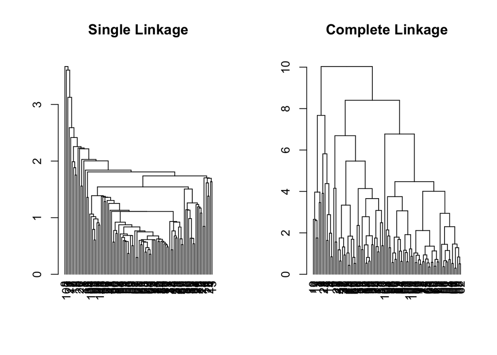

```r
#run hierarchical clustering
hc.spotify.single = hclust(dist.spotify, method = "single")
hc.spotify.complete = hclust(dist.spotify, method = "complete")
#convert to dendrograms
hc.spotify.single.dend = as.dendrogram(hc.spotify.single)
hc.spotify.complete.dend = as.dendrogram(hc.spotify.complete)
#make the dendrogram plots
par(mfrow=c(1,2))
plot(hc.spotify.single.dend, main = "Single Linkage")
plot(hc.spotify.complete.dend, main = "Complete Linkage")
```

After you’ve made your two plots, in 1-2 sentences, compare the overall “shape” of the tree (i.e., the clustering structure) between the “single linkage” tree and the “complete linkage” tree.

2. (10pts) To better understand the clustering structure between “single linkage” and “complete linkage,” it can be helpful to color the tree by the clusters it naturally divides itself into. For this part, recreate the plots from Part A, but color each tree with $k = 3$ colors, and include those colored trees here. To do this, use the `set` function in the `dendextend` `R` library. We went over how to do this in lab, but your code should look something like the following:

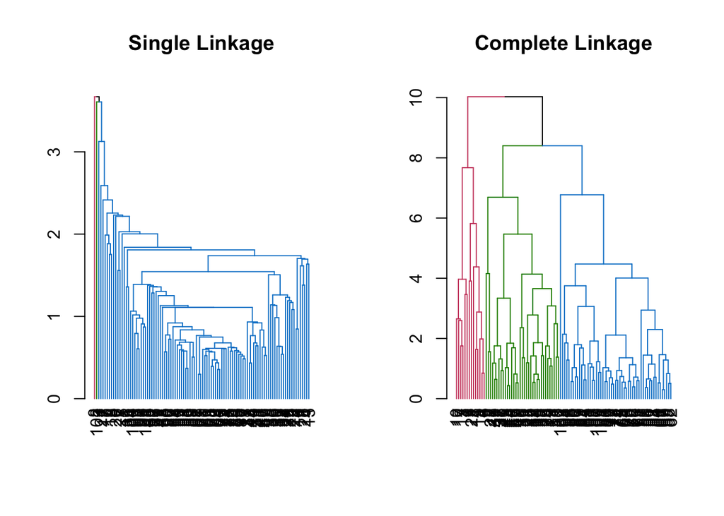

```r
library(dendextend)
hc.spotify.single.dend = set(hc.spotify.single.dend, "branches_k_color", k=3)
hc.spotify.complete.dend = set(hc.spotify.complete.dend, "branches_k_color", k=3)

par(mfrow=c(1,2))
plot(hc.spotify.single.dend, main = "Single Linkage")
plot(hc.spotify.complete.dend, main = "Complete Linkage")
```

where `hc.spotify.complete.dend` is the `dendrogram` object you should have created in Part A using “complete linkage” (the “single linkage” code will be analogous).

After you do this, in 1-2 sentences, compare and contrast these two trees. (The “single linkage” tree should look particularly odd.)

*At first glance, it appears like the “single linkage” tree is just one color, while there are three colors for “complete linkage.” However, there technically are three colors for “single linkage” - if you look closely, you can see a tiny little branch that’s red, and another that’s green. This is because there is only a single observation in each of these two clusters, as we verify next.*

3. (5pts) Let’s better understand what’s going on in Part B. [In the background](https://www.youtube.com/watch?v=LIc6OIPZMHg), the code provided in Part B uses the `cutree` function (look up the help documentation for this). Run the code `cutree(hc.spotify.complete.dend, k = 3)` in the Console to see what this function does (see Part B to know what I mean by `hc.spotify.complete.dend`).

```r
hc3.single = cutree(hc.spotify.single.dend, k = 3)
hc3.complete = cutree(hc.spotify.complete.dend, k = 3)
table(hc3.single)
```

```
## hc3.single
##   1   2   3
## 100   1   1
```

```r
table(hc3.complete)
```

```
## hc3.complete
##  1  2  3
## 35 14 53
```

After you’ve done that: How many observations are in each of the $k = 3$ groups produced by “complete linkage” hierarchical clustering? How about by “single linkage” hierarchical clustering? In this part, be sure to provide code that allows you to answer these questions (and be sure to answer the two questions themselves).

*From the above, we can see that there are 100 observations, one observation, and one observation in the three clusters from “single linkage.” Meanwhile, there are 35 observations, 14 observations, and 53 observations in the three clusters from “complete linkage.” Thus, the cluster-specific sample sizes are more evenly distributed for “complete linkage” than for “single linkage.”*

4. (10pts) **The odd behavior in Part B is why people usually prefer “complete linkage” over “single linkage,” so please focus on “complete linkage” for this part.** As discussed in lab, we can also use the `set` function to color the leaf labels in a dendrogram. In this part, you must color the leaf labels by the `decades` variable. To do this, do the following things:
- First, create an object called `spotify.decades.colors`, which is a vector of colors, one for each `decades` value (there are 5). In other words, this should be a vector of length 102 (the number of observations in the dataset), where there is one color for each `decades` value in the dataset. Since there are five unique `decades` in the dataset, there should be five unique colors in `spotify.decades.colors` - you can choose any colors you want.

```r
#create colors for the three areas
spotify.decades.colors = ifelse(spotify$decades == "1920s-30s", "blue",
    ifelse(spotify$decades == "1940s-50s", "red",
           ifelse(spotify$decades == "1960s-1970s", "green",
                  ifelse(spotify$decades == "1980s-1990s", "orange", "purple"))))
```

- *After* you used `set` to “set” the “branches_k_color” to be $k = 3$ for your `dendrogram` object (as in Part B), run the following code:

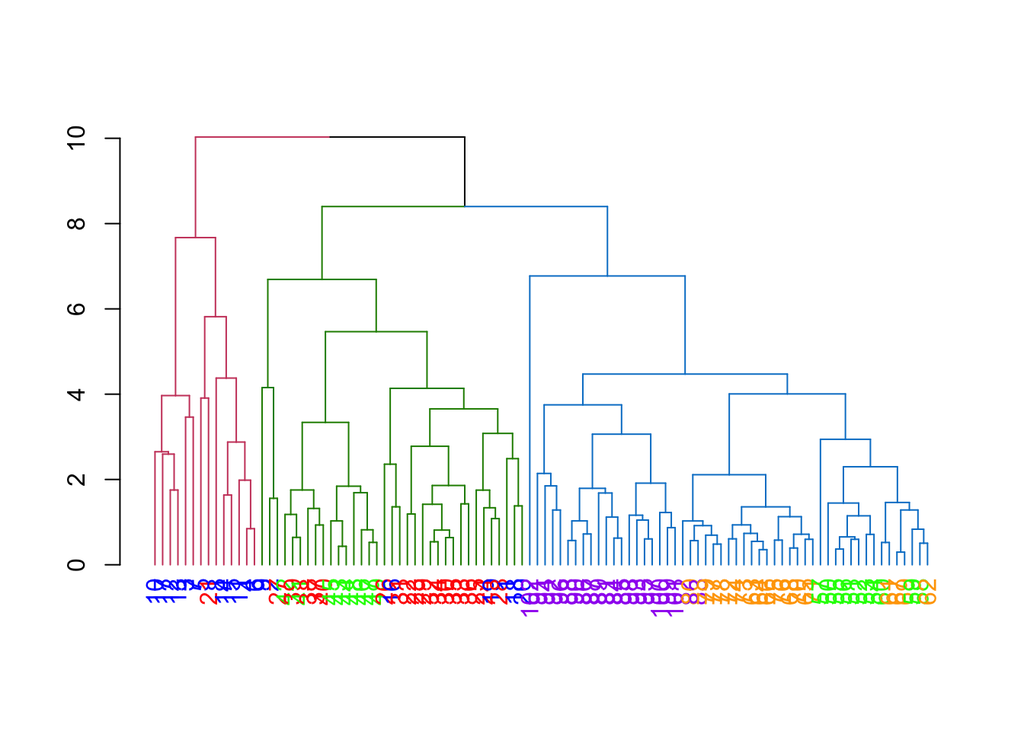

```r
hc.spotify.complete.dend = set(hc.spotify.complete.dend, "labels_colors", order_value = TRUE, spotify.decades.colors)
plot(hc.spotify.complete.dend)
```

This code requires that you have `hc.spotify.complete.dend` correctly defined (see Part B) as well as `spotify.decades.colors` defined.

After you run the above code and make your plot with branch and leaf label colors (which you should include in your submission), in 1-3 sentences, characterize the three clusters identified by the dendrogram in terms of the `decades` variable. In particular, to what extent are the three clusters identified by our dendrogram characterized by particular `decades` in the dataset?

# Problem 2: The Principal Components of Music (40 points)

Now Professor Clark would like you to use principal component analysis to visualize the `spotify` dataset from Problem 1.

1. (8pts) For this part, perform the following tasks:
- Create a subset of the `spotify` dataset that only contains the 11 quantitative characteristics mentioned in Problem 1. Call this `spotify.subset`. (You should have already made a similar subset in Problem 1.)

```r
spotify.subset = subset(spotify, select = -c(year, decades))
```

- Run principal components analysis (PCA) on `spotify.subset`. Be sure that the columns of `spotify` are *centered* and *standardized* when you run PCA.

```r
#center and standardize the columns
spotify.subset = apply(spotify.subset, MARGIN = 2, FUN = function(x) x - mean(x))
spotify.subset = apply(spotify.subset, MARGIN = 2, FUN = function(x) x/sd(x))
#note that, alternatively, you can just set center = TRUE
#and scale. = TRUE to center/standardize your variables.
spotify.pca = prcomp(spotify.subset, center = TRUE,scale. = TRUE)
summary(spotify.pca)
```

```
## Importance of components:
##                           PC1    PC2     PC3     PC4    PC5     PC6     PC7
## Standard deviation     2.4516 1.3663 1.02185 0.93696 0.7828 0.54808 0.33198
## Proportion of Variance 0.5464 0.1697 0.09492 0.07981 0.0557 0.02731 0.01002
## Cumulative Proportion  0.5464 0.7161 0.81102 0.89083 0.9465 0.97384 0.98386
##                           PC8     PC9    PC10    PC11
## Standard deviation     0.2947 0.22214 0.18315 0.08836
## Proportion of Variance 0.0079 0.00449 0.00305 0.00071
## Cumulative Proportion  0.9918 0.99624 0.99929 1.00000
```

Then, answer the following questions: What proportion of the total variation in the data is accounted by the first principal component specifically? By the second principal component specifically? By both the first and second principal components together?

*From the output above, we can determine the following:*

- *0.5464 = 54.64% of the total variation is accounted by the first principal component.*
- *0.1697 = 16.97% of the total variation is accounted by the second principal component.*
- *0.7161 = 71.61% of the total variation is accounted by the first and second principal components together. [You can figure this out either by adding up the two previous numbers, or looking at the “Cumulative Proportion” row in the above output.*
2. (7pts) In class and lab we discussed using an *elbow plot* (or scree plot) to determine how many principal components should be used for visualization. For this part, create an elbow plot for these data, where the component numbers (1 through 11) are on the x-axis, and the proportion of total variation is on the y-axis.

*One way to make the elbow plot is using the `plot()` function, as shown in the Lecture 17 R demo:*

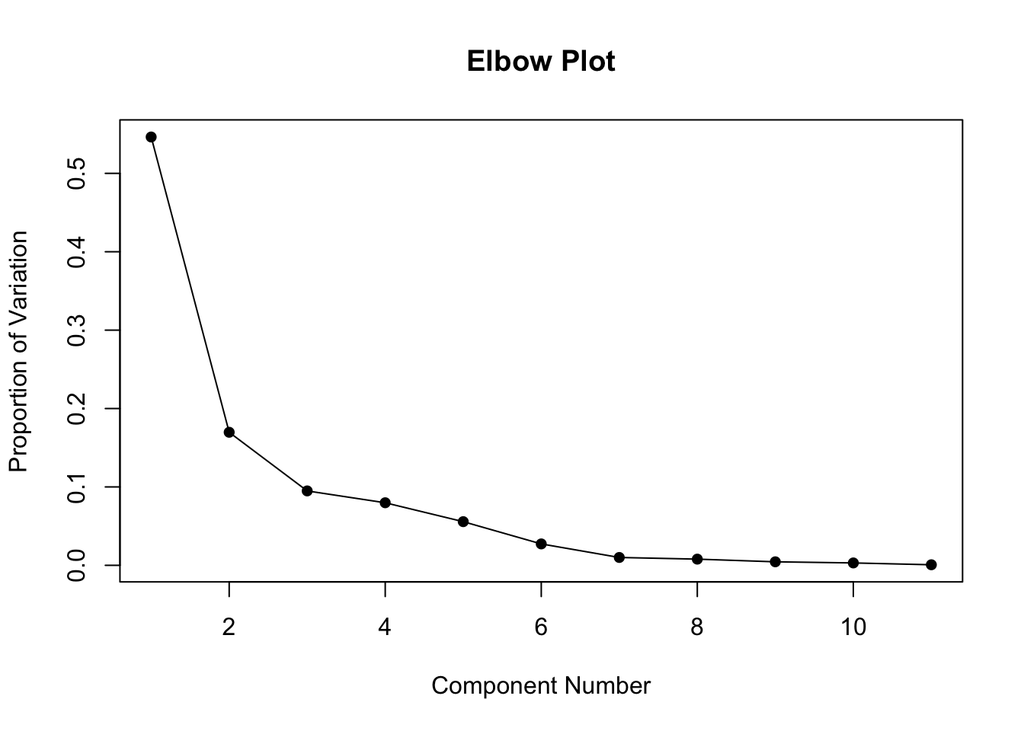

```r
#Here is the proportion of variance accounted by each principal component:
varProps = summary(spotify.pca)$importance["Proportion of Variance",]
#draw the line
plot(1:ncol(spotify.subset), varProps, type = "l",
     xlab = "Component Number", ylab = "Proportion of Variation",
     main = "Elbow Plot")
#add the points
points(1:ncol(spotify.subset), varProps, pch = 16)
```

*Alternatively, you could use `ggscreeplot()` within the `ggbiplot` R package*:

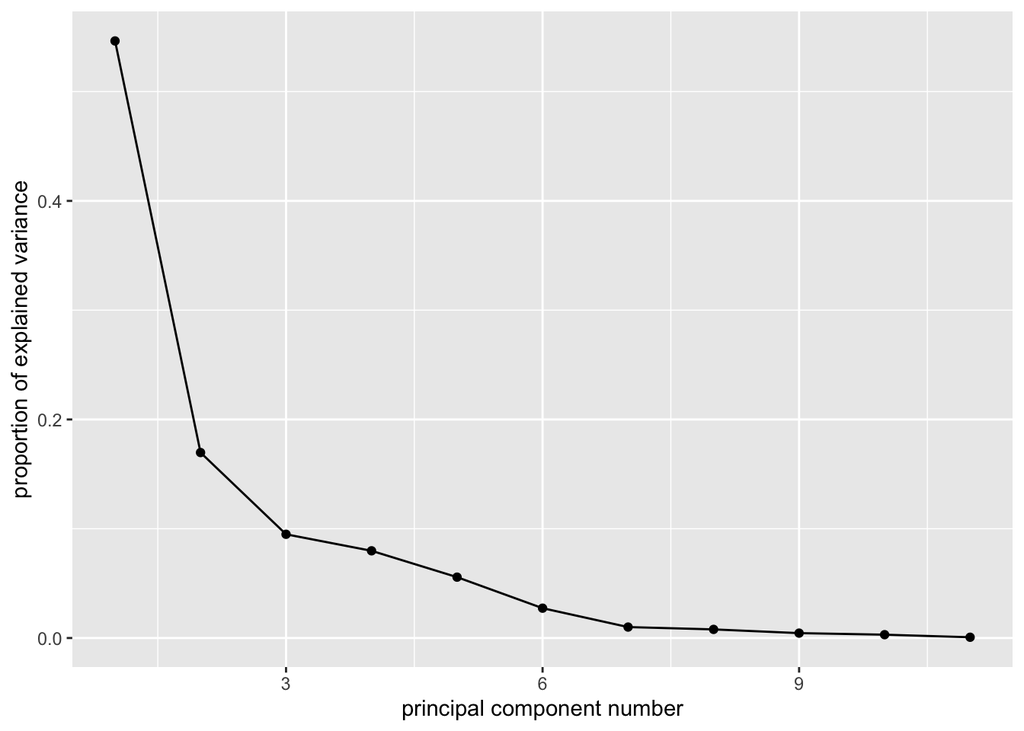

```r
library(ggbiplot)
ggscreeplot(spotify.pca)
```

After you’ve made your plot: Based on the plot, how many principal components do you think should be used for visualizations and analyses? Provide a 1-2 sentence explanation.

*In any case, the elbow plot seems to clearly suggest that we should visualize $k = 3$ principal components: After $k = 3$, the line in the above elbow plot begins to “level off” quite a lot, thereby signaling that there is not much additional benefit (in terms of total variation) in adding more principal components in our visualizatoins/analyses. That said, a weaker argument can be made for $k = 7$, because the proportion of variation certainly levels off at this point as well. However, by the time we get to $k = 7$, the proportion of variation is already near 0. Furthermore, it’s worth noting that the purpose of PCA is to reduce the dimensionality of the data - going from 11 to 3 dimensions is certainly a large dimension reduction, but from 11 to 7 doesn’t make our data visualization lives all that much easier. This is all the more reason to prefer $k = 3$ over $k = 7$.*

3. (15pts) Professor Clark now asks you to use `ggplot()` to make the following scatterplots:
- A scatterplot with the first principal component on the x-axis and the second principal component on the y-axis, with points colored by `decades`.

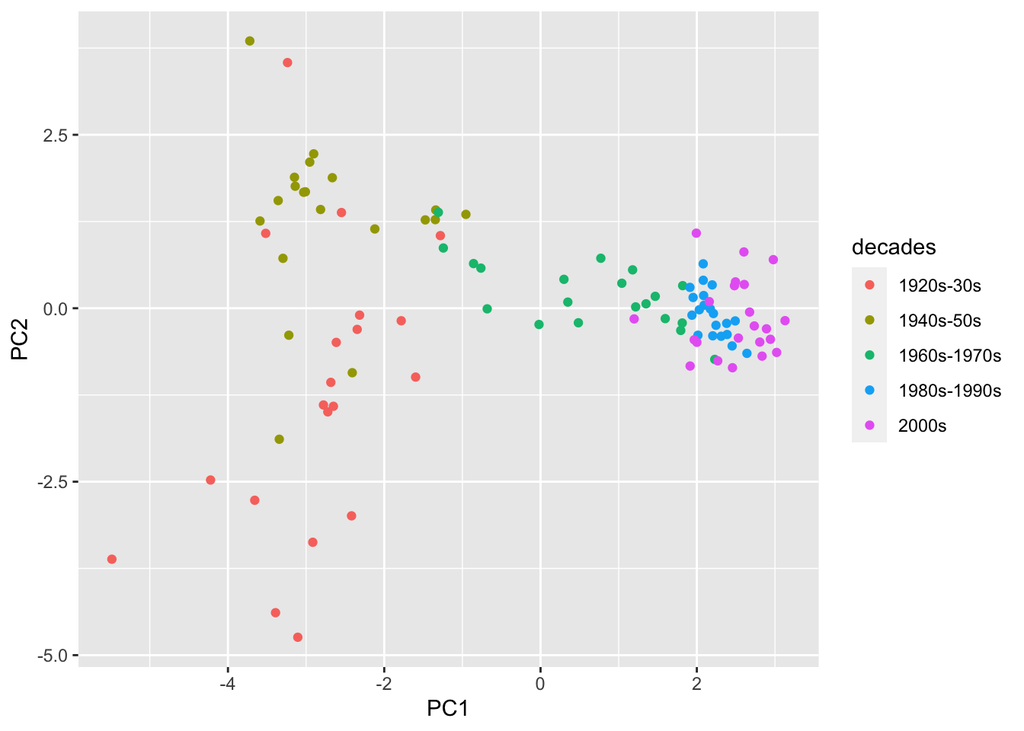

```r
#get the "rotation" from PCA:
rotation.pca = as.matrix(spotify.pca$rotation)
#Compute principal components, which is defined as X \times rotation:
prinComps = as.matrix(spotify.subset)%*%rotation.pca
#convert it to a data frame
prinComps = as.data.frame(prinComps)
#add decades to this data.frame
prinComps$decades = spotify$decades
library(tidyverse)
ggplot(prinComps, aes(x = PC1, y = PC2)) + geom_point(aes(color = decades))
```

- A scatterplot with the first principal component on the x-axis and the third principal component on the y-axis, with points colored by `decades`.

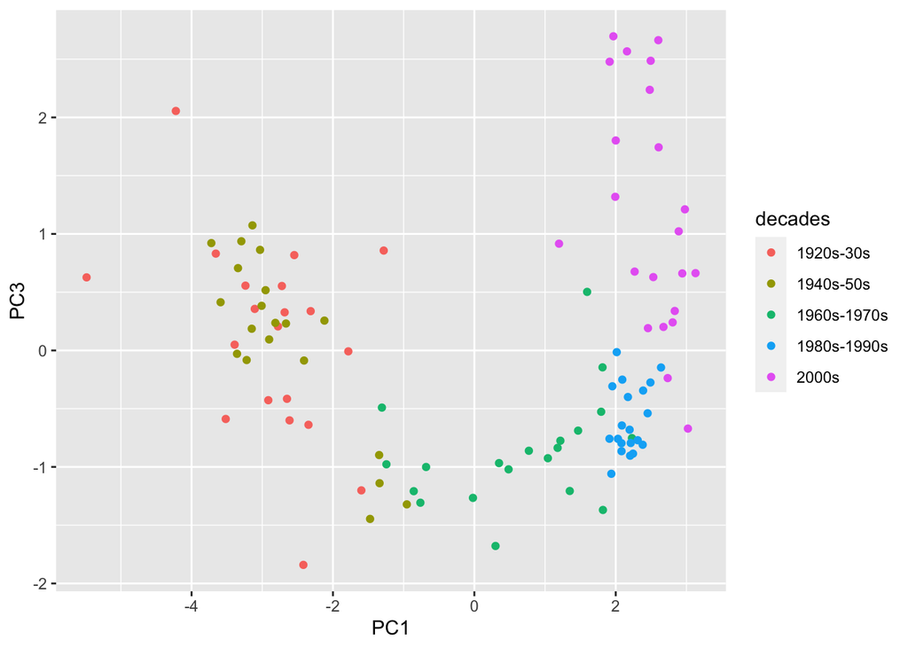

```r
ggplot(prinComps, aes(x = PC1, y = PC3)) + geom_point(aes(color = decades))
```

Then, for your each plot, discuss your main observations in 1-3 sentences. In particular: In what ways does `decades` seem to be associated with each of the principal components you are visualizing in each plot?

**Hint**: This problem asks you to use `ggplot()` specifically to make the scatterplots; the Lecture 17 `R` demo walked through how to use the base `R` `plot()` function and the `ggbiplot()` function to make scatterplots of principal components. In order to use `ggplot()`, you’ll have to put the principal components and the `decades` variable into a single `data.frame`.

*In both plots, we can see that earlier songs tend to have lower values of the first principal component: Songs from the 1920s to 1950s are on the left side of the plot, while songs from the 1980s to 2000s are on the right side of the plot. Meanwhile, in the first plot, we can see that songs from the 1920s to 1950s tend to have a lot of variation in the second principal component (in particular, songs in the 1920s tend to have lower values of this component), but other songs (from the 1960s onward) tend to have a second principal component value around 0. Finally, in the second plot, we can see a very interesting U shape: Old and recent songs both tend to have higher values of the third principal component, whereas sounds in the 1960s and 1970s tend to have a low value of the third principal component.*

4. (10pts) Professor Clark found your Part C observations interesting, but she rightfully notes that the principal components aren’t interpretable by themselves, thereby limiting the observations you can make about the data. In this part we’ll explore in what ways the **first two principal components** are related to the original variables in the data.

For this part you should do **one** of the following two tasks of your choice (i.e., you **do not** have to do both tasks - just do one or the other, whichever you prefer). In your submission for this part, write, “I decided to do Task 1” or “I decided to do Task 2,” and then provide your work for one of the following tasks:

1. Use `ggbiplot()` to make a biplot of the first two principal components, as shown in the Lecture 17 R demo. To do this, you must follow these steps:
- First you need to install the `ggbiplot` library, which unfortunately may be challenging for some of you (in which case you may prefer to do the second task instead). First, you must install the R package `devtools`. Then, load `library(devtools)` in the Console, and then type `install_github("vqv/ggbiplot")`. For some versions of R, you might have to also write `force = TRUE` within `install_github()`. Hopefully this will go smoothly, in which case you can run `library(ggbiplot)` and then continue to the next step.
- Then, use `ggbiplot()` to make a biplot of the first two principal components. Specify the `groups` argument such that the points are colored by `decades`. When you make this plot, unfortunately, it may be difficult to see some of the variable names on the arrows; if that is the case for you, put `varname.adjust = -0.5` within `ggbiplot()`, such that you can see all of the variable names.

After you’ve made the biplot, discuss in 1-4 sentences in what ways `decades` is associated with the original variables in the data.

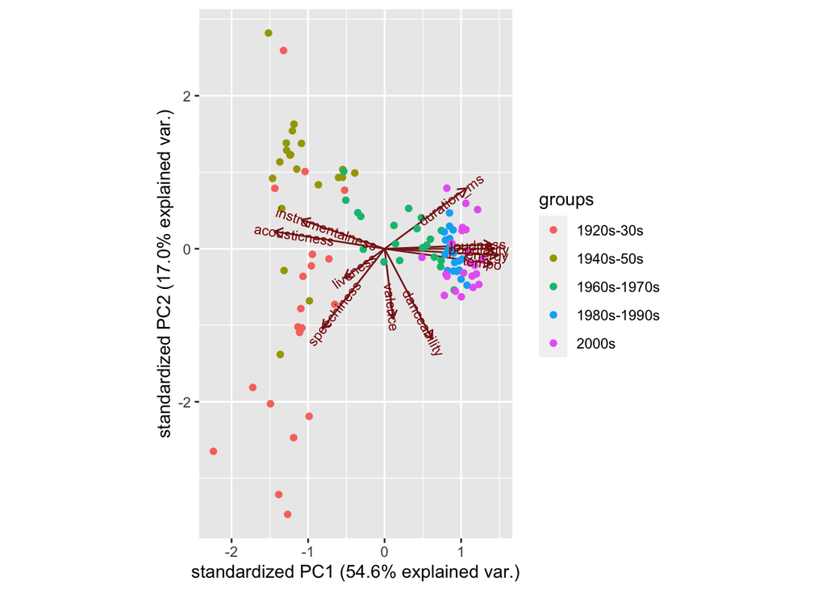

```r
library(ggbiplot)
ggbiplot(spotify.pca, group = prinComps$decades, varname.adjust = -0.5)
```

*From the biplot, we can see that the variables loudness, popularity, energy, and tempo all point towards the right, thereby signaling that songs with a high first principal component tend to have higher values of these variables. [It can be somewhat difficult to read these variable names in the plot - I typed `names(spotify)` in the Console to pinpoint which variables are pointing to the right.] Thus, more recent songs (especially from the 1980s to the 2000s) tend to have more loudness, popularity, energy, and tempo. This is intuitive - we would expect more recent songs on Spotify to be more popular, as well as have more energy and tempo; furthermore, it’s been [well-documented](https://en.wikipedia.org/wiki/Loudness_war) that songs tend to be louder over time.*

*Furthermore, we can see that duration and danceability somewhat point towards the right, further indicating that more recent songs tend to be longer and are more “danceable.”*

*Meanwhile, by the same reasoning, it appears that older songs (especially those from the 1920s to 1950s) tend to have more instrumentalness, acousticness, liveness, and speechiness. Furthermore, because valence points downward and songs from the 1920s and 1930s tend to have small second principal component values, this indicates that songs from the 1920s and 1930s tend to have higher valence as well.*

*[Note that this dataset describes songs with 11 different variables. If I asked you - as a first question - to determine if a song’s time period is associated with these other 11 variables, you would probably make many graphs and become overwhelmed. In this problem, I tried to outline how you can use PCA to ascertain whether one variable (`decades`) is associated with 11 other variables, using just one or two plots!]*

2. In Part C you should have used the `prcomp()` function as well as a “rotation matrix” to create the principal components. After you’ve done that, you should be able to edit and uncomment the following line of code:

```r
spotify.pca$rotation
```

```
##                          PC1           PC2         PC3         PC4         PC5
## acousticness     -0.38575861  0.1085900898 -0.16239117  0.11315170 -0.16528827
## danceability      0.16627837 -0.5667538387  0.24305589 -0.28566083 -0.34573298
## duration_ms       0.28715494  0.3804845918  0.12576351  0.05016548  0.05281047
## energy            0.39719962 -0.0412769645  0.16790472  0.02917167 -0.01916810
## instrumentalness -0.29082115  0.1820894232  0.37315639  0.02356918 -0.64379465
## liveness         -0.14120574 -0.1833394812  0.51516938  0.74201971  0.29886849
## loudness          0.37676297  0.0268997403  0.19828770  0.11936617 -0.19383962
## speechiness      -0.21755768 -0.5009888710  0.21971730 -0.31186431  0.34167746
## tempo             0.37631946 -0.0942041209  0.09567893  0.10965297 -0.23833195
## valence           0.02990961 -0.4395087140 -0.57935016  0.47650933 -0.28940974
## popularity        0.38341583 -0.0005214302 -0.18304245  0.02203898  0.22654097
##                          PC6         PC7         PC8         PC9        PC10
## acousticness      0.07128254 -0.10079933  0.41138352 -0.08012117  0.47869024
## danceability     -0.11626131 -0.18482422  0.28290393 -0.50379328 -0.09244183
## duration_ms      -0.83526884 -0.02158831  0.20761129 -0.03478453  0.09057220
## energy            0.06422141 -0.06563878 -0.25917417  0.22405795 -0.33155153
## instrumentalness -0.11500637 -0.10949502 -0.52240554  0.04920605  0.15304706
## liveness          0.02211606 -0.02322984  0.02643518 -0.19736114 -0.01564538
## loudness          0.26085442 -0.44944198  0.36233576  0.50993054  0.21285663
## speechiness      -0.27848263  0.03425747 -0.13583989  0.45233598  0.36525633
## tempo             0.12183826  0.78656263  0.04321464  0.01739160  0.36852017
## valence          -0.31128874 -0.06952132 -0.11827091  0.19373577 -0.06600518
## popularity        0.09244056 -0.33420139 -0.44861310 -0.38015173  0.54920698
##                          PC11
## acousticness     -0.594022079
## danceability     -0.029454163
## duration_ms      -0.031554869
## energy           -0.758541897
## instrumentalness  0.063450330
## liveness          0.014446287
## loudness          0.243964244
## speechiness      -0.064819974
## tempo             0.005145761
## valence           0.043123347
## popularity       -0.006912296
```

where `spotify.pca` is the object appropriately defined by `prcomp()`. You should be able to see an 11-by-11 matrix, where the rows correspond to the original variables and the columns correspond to the principal components. Each column represents the *linear combination* of the variables that each principal component represents (as discussed in class). In particular: Each number tells you how the variable is associated with the principal component. If a number is positive, that means songs with a higher value of that principal component also tend to have a higher value of that variable. Similarly, if a number is negative, that means songs with a *lower* value of that principal component tend to have a higher value of that variable.

Now look back at the first plot you made in Part C, which visualizes the first two principal components (colored by `decades`). Given these details about the rotation matrix, discuss in 1-4 sentences in what ways `decades` is associated with the original variables in the data. Be sure to explain how you used the rotation matrix output to arrive at your answer.

*This problem asked you to focus only on the first two principal components, and thus we only needed to examine the first two columns of the rotation matrix:*

```r
spotify.pca$rotation[,1:2]
```

```
##                          PC1           PC2
## acousticness     -0.38575861  0.1085900898
## danceability      0.16627837 -0.5667538387
## duration_ms       0.28715494  0.3804845918
## energy            0.39719962 -0.0412769645
## instrumentalness -0.29082115  0.1820894232
## liveness         -0.14120574 -0.1833394812
## loudness          0.37676297  0.0268997403
## speechiness      -0.21755768 -0.5009888710
## tempo             0.37631946 -0.0942041209
## valence           0.02990961 -0.4395087140
## popularity        0.38341583 -0.0005214302
```

*Note that the sign of these numbers corresponds exactly to the direction of the arrows of the biplot; indeed, the arrows are simply a visualization of the two-dimensional vector in each row of this matrix. For example, we see that acousticness has a negative number for the first principal component (and thus it points to the left of the biplot) and a positive number for the second principal component (and thus it points upwards on the biplot).*

*Thus, using these numbers, we can make the exact same conclusions as we did above about `decades` and the 11 variables in the dataset. It is more tedious to stare at 22 different numbers in this rotation matrix, but this demonstrates another way that you can ascertain how the principal components are related to the original variables in your data, and thus how a variable like `decades` is related to other variables in your data as well.*